# Study 2 — Emotional valence and visual contrast

- Show All Code
- Hide All Code
- View Source

Does perceptual fluency shape intuitive coherence judgments like affective fluency?

Author

Przemysław Marcowski

Published

July 16, 2026

```r
e2 <- readRDS(here("data/processed/prepared/exp2.Rds"))

behav <- e2 %>%
  group_by(participant_id, triad_solvable, affect, contrast, trial) %>%
  summarise(accuracy = first(accuracy), rt = first(accuracy_rt),
            confidence = first(confidence), .groups = "drop")
```

# 1 Overview

Study 2 crossed **emotional valence** (Negative, Neutral, Positive) with **visual contrast** (a *perceptual* fluency source: the solvable triad, the nonsolvable triad, both, or neither shown in high contrast). If all fluency sources act alike, contrast should shape response time and confidence as valence did in Study 1. The analysed sample is *N* = 45.

**NoteModel specification**

Omnibus effects use **Type III tests** (`emmeans::joint_tests()`, invariant to contrast coding) on `affect * contrast` models with by-participant and by-position random intercepts; the maximal by-participant slope is singular and is not retained.

```r
cohen_d <- function(model, contrasts) emm_df(contrasts) %>% mutate(d = estimate / sigma(model))
```

## 1.1 Accuracy (H1)

```r
acc_data <- behav %>% filter(!is.na(accuracy))
acc_tests <- acc_data %>%
  group_by(affect, contrast) %>%
  summarise(successes = sum(accuracy), trials = n(), prop = successes / trials,
            p_value = binom.test(successes, trials, 0.5, "greater")$p.value, .groups = "drop")
acc_model <- glmmTMB(accuracy ~ affect * contrast + (1 | participant_id) + (1 | trial),
                     data = acc_data, family = binomial)
acc_omnibus <- joint_tests(acc_model)
write_csv(acc_tests, file.path(out_dir, "accuracy_tests.csv"))
write_csv(acc_omnibus, file.path(out_dir, "accuracy_effects.csv"))
knitr::kable(acc_omnibus, digits = 3, caption = "Accuracy: Type III omnibus tests.")
```

Accuracy: Type III omnibus tests.

|  | model term | df1 | df2 | F.ratio | Chisq | p.value |
| --- | --- | --- | --- | --- | --- | --- |
| 1 | affect | 2 | Inf | 0.390 | 0.780 | 0.677 |
| 3 | contrast | 3 | Inf | 0.816 | 2.448 | 0.485 |
| 2 | affect:contrast | 6 | Inf | 0.742 | 4.452 | 0.616 |

Accuracy was again at ceiling (all conditions above chance, all *p*s < .001) and unaffected by valence, contrast, or their interaction (all *p*s > .05).

## 1.2 Response time (H2)

```r
rt_data <- behav %>% filter(!is.na(rt)) %>% mutate(log_rt = log(rt))
rt_model <- glmmTMB(log_rt ~ affect * contrast + (1 | participant_id) + (1 | trial), data = rt_data)
rt_omnibus <- joint_tests(rt_model)
rt_emm <- emmeans(rt_model, ~ affect | contrast)
rt_contrasts <- cohen_d(rt_model, summary(contrast(rt_emm, "pairwise", adjust = "fdr"), infer = TRUE))
write_csv(rt_omnibus, file.path(out_dir, "rt_effects.csv"))
write_csv(emm_df(rt_emm), file.path(out_dir, "rt_means.csv"))
write_csv(rt_contrasts, file.path(out_dir, "rt_contrasts.csv"))
knitr::kable(rt_omnibus, digits = 3, caption = "Response time: Type III omnibus tests.")
```

Response time: Type III omnibus tests.

|  | model term | df1 | df2 | F.ratio | Chisq | p.value |
| --- | --- | --- | --- | --- | --- | --- |
| 1 | affect | 2 | Inf | 1.356 | 2.712 | 0.258 |
| 3 | contrast | 3 | Inf | 0.477 | 1.431 | 0.698 |
| 2 | affect:contrast | 6 | Inf | 1.824 | 10.944 | 0.090 |

Neither valence, contrast, nor their interaction significantly affected response time (see table). Contrary to the perceptual-fluency prediction, high contrast did not speed responses, and the affect effect seen in Study 1 did not clearly replicate here.

## 1.3 Confidence (H3)

```r
conf_data <- behav %>% filter(!is.na(confidence))
conf_model <- glmmTMB(confidence ~ affect * contrast + (1 | participant_id) + (1 | trial), data = conf_data)
conf_omnibus <- joint_tests(conf_model)
conf_emm <- emmeans(conf_model, ~ affect | contrast)
conf_contrasts <- cohen_d(conf_model, summary(contrast(conf_emm, "pairwise", adjust = "fdr"), infer = TRUE))
write_csv(conf_omnibus, file.path(out_dir, "confidence_effects.csv"))
write_csv(emm_df(conf_emm), file.path(out_dir, "confidence_means.csv"))
write_csv(conf_contrasts, file.path(out_dir, "confidence_contrasts.csv"))
knitr::kable(conf_omnibus, digits = 3, caption = "Confidence: Type III omnibus tests.")
```

Confidence: Type III omnibus tests.

|  | model term | df1 | df2 | F.ratio | Chisq | p.value |
| --- | --- | --- | --- | --- | --- | --- |
| 1 | affect | 2 | Inf | 9.010 | 18.020 | 0.000 |
| 3 | contrast | 3 | Inf | 0.469 | 1.407 | 0.704 |
| 2 | affect:contrast | 6 | Inf | 1.429 | 8.574 | 0.199 |

```r
# The maximal by-participant slope model is singular, so the reported models use
# random intercepts.
conf_slope_model <- glmmTMB(confidence ~ affect * contrast + (affect | participant_id) + (1 | trial),
                            data = conf_data)
performance::check_singularity(conf_slope_model)
```

```
[1] TRUE
```

Valence again shaped confidence (a main effect of affect), partially replicating Study 1, whereas contrast and the affect × contrast interaction did not.

## 1.4 Gaze preference (H4)

```r
tsd <- make_time_sequence_data(e2, time_bin_size = bin_size, aois = c("Solvable", "Nonsolvable"),
                               predictor_columns = c("affect", "contrast"),
                               summarize_by = c("participant_id", "trial"))
preference <- tsd %>%
  pivot_wider(id_cols = c(participant_id, trial, affect, contrast, Time, ot1:ot4),
              names_from = AOI, values_from = SamplesInAOI, names_prefix = "looks_") %>%
  mutate(total = looks_Solvable + looks_Nonsolvable,
         preference = (looks_Solvable - looks_Nonsolvable) / total) %>%
  filter(total > 0)
# The correlated time-slope block exceeds the default evaluation limits, so the
# optimizer budget is enlarged.
gca <- glmmTMB(preference ~ affect * contrast * (ot1 + ot2 + ot3 + ot4) +
                 (1 + ot1 + ot2 + ot3 + ot4 | participant_id) + (1 | trial),
               data = preference, weights = total,
               control = glmmTMBControl(optCtrl = list(iter.max = 2000, eval.max = 2000)))
gca_omnibus <- joint_tests(gca)
gca_emm <- emmeans(gca, ~ affect | contrast)
gca_contrasts <- cohen_d(gca, summary(contrast(gca_emm, "pairwise", adjust = "fdr"), infer = TRUE))
write_csv(gca_omnibus, file.path(out_dir, "preference_effects.csv"))
write_csv(emm_df(gca_emm), file.path(out_dir, "preference_means.csv"))
write_csv(gca_contrasts, file.path(out_dir, "preference_contrasts.csv"))
```

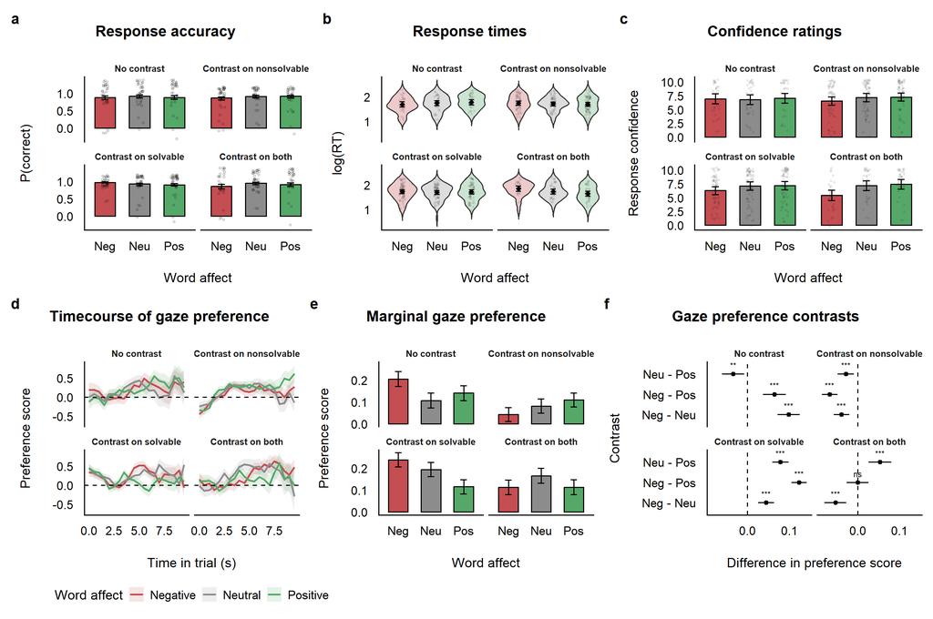

```r
# Six-panel layout (a–f), 2 × 2 contrast facets.
lab <- labeller(contrast = contrast_labels)
affect_abbrev <- c(Negative = "Neg", Neutral = "Neu", Positive = "Pos")

p_acc <- acc_data %>% group_by(participant_id, affect, contrast) %>%
  summarise(prob = mean(accuracy), .groups = "drop") %>%
  ggplot(aes(affect, prob, fill = affect)) +
  geom_col(data = acc_tests, aes(y = prop), width = 0.6, colour = "black") +
  geom_jitter(width = 0.1, alpha = 0.25, shape = 1, size = 0.8) +
  stat_summary(fun.data = mean_se, geom = "errorbar", width = 0.2) +
  facet_wrap(~ contrast, labeller = lab, nrow = 2) +
  scale_fill_manual(values = affect_colours, guide = "none") +
  scale_x_discrete(labels = affect_abbrev) +
  labs(title = "Response accuracy", x = "Word affect", y = "P(correct)")

p_rt <- ggplot(rt_data, aes(affect, log_rt)) +
  geom_violin(aes(fill = affect), alpha = 0.3, trim = FALSE) +
  geom_jitter(width = 0.08, alpha = 0.12, shape = 1, size = 0.7) +
  geom_errorbar(data = emm_df(rt_emm), aes(y = emmean, ymin = lower.CL, ymax = upper.CL), width = 0.15) +
  geom_point(data = emm_df(rt_emm), aes(y = emmean), size = 2.5, shape = 18) +
  facet_wrap(~ contrast, labeller = lab, nrow = 2) +
  scale_fill_manual(values = affect_colours, guide = "none") +
  scale_x_discrete(labels = affect_abbrev) +
  labs(title = "Response times", x = "Word affect", y = "log(RT)")

p_conf <- ggplot(emm_df(conf_emm), aes(affect, emmean, fill = affect)) +
  geom_col(width = 0.6, colour = "black") +
  geom_jitter(data = conf_data, aes(affect, confidence), inherit.aes = FALSE,
              width = 0.1, alpha = 0.12, shape = 1, size = 0.7) +
  geom_errorbar(aes(ymin = lower.CL, ymax = upper.CL), width = 0.2) +
  facet_wrap(~ contrast, labeller = lab, nrow = 2) +
  scale_fill_manual(values = affect_colours, guide = "none") +
  scale_x_discrete(labels = affect_abbrev) +
  labs(title = "Confidence ratings", x = "Word affect", y = "Response confidence")

p_time <- ggplot(preference, aes(Time, preference, colour = affect, fill = affect)) +
  stat_summary(geom = "ribbon", fun.data = mean_se, colour = NA, alpha = 0.15) +
  stat_summary(geom = "line", fun = mean, linewidth = 0.9) +
  geom_hline(yintercept = 0, linetype = "dashed") +
  facet_wrap(~ contrast, labeller = lab, nrow = 2) +
  scale_colour_manual(values = affect_colours) + scale_fill_manual(values = affect_colours) +
  labs(title = "Timecourse of gaze preference", x = "Time in trial (s)", y = "Preference score",
       colour = "Word affect", fill = "Word affect")

p_pref <- ggplot(emm_df(gca_emm), aes(affect, emmean, fill = affect)) +
  geom_col(width = 0.6, colour = "black") +
  geom_errorbar(aes(ymin = lower.CL, ymax = upper.CL), width = 0.2) +
  facet_wrap(~ contrast, labeller = lab, nrow = 2) +
  scale_fill_manual(values = affect_colours, guide = "none") +
  scale_x_discrete(labels = affect_abbrev) +
  labs(title = "Marginal gaze preference", x = "Word affect", y = "Preference score")

contr_plot <- gca_contrasts %>%
  rename(pair = 1) %>%
  mutate(pair = pair %>% gsub("Negative", "Neg", x = .) %>% gsub("Neutral", "Neu", x = .) %>%
           gsub("Positive", "Pos", x = .),
         sig = as.character(sig_stars(p.value)))
p_contr <- ggplot(contr_plot, aes(estimate, pair)) +
  geom_vline(xintercept = 0, linetype = "dashed") +
  geom_pointrange(aes(xmin = lower.CL, xmax = upper.CL), size = 0.3) +
  geom_text(aes(label = sig), vjust = -0.9, size = 3) +
  facet_wrap(~ contrast, labeller = lab, nrow = 2) +
  scale_x_continuous(n.breaks = 3) +
  labs(title = "Gaze preference contrasts", x = "Difference in preference score", y = "Contrast")

figure <- (p_acc | p_rt | p_conf) / (p_time | p_pref | p_contr) + plot_annotation(tag_levels = "a")
ggsave(file.path(out_dir, "figure.png"), figure, width = 14, height = 9.3, dpi = 300)
figure
```

## 1.5 Correlations

```r
inspect <- e2 %>%
  group_by(participant_id, affect, contrast, trial) %>%
  summarise(inspection = sum(Solvable, na.rm = TRUE),
            accuracy = first(accuracy), confidence = first(confidence), .groups = "drop")
conf_rm <- inspect %>% filter(!is.na(confidence)) %>% mutate(participant_id = factor(participant_id)) %>%
  rmcorr(participant_id, inspection, confidence, dataset = .)
correlations <- tibble(
  analysis = "confidence ~ inspection (rmcorr)",
  estimate = conf_rm$r, ci_low = conf_rm$CI[1], ci_high = conf_rm$CI[2], p_value = conf_rm$p)
write_csv(correlations, file.path(out_dir, "correlations.csv"))
```

As in Study 1, longer inspection of the solvable triad was associated with **lower** confidence (rmcorr *r* = -0.27, *p* < .001).

## 1.6 Supplementary tables

```r
# Raw condition-level descriptives complementing the model-based estimates above.
descriptives <- behav %>%
  pivot_longer(c(accuracy, rt, confidence), names_to = "outcome") %>%
  filter(!is.na(value)) %>%
  group_by(outcome, affect, contrast) %>%
  summarise(n = n(), mean = mean(value), sd = sd(value), se = sd / sqrt(n), .groups = "drop")
write_csv(descriptives, file.path(out_dir, "descriptives.csv"))

# Specification and fit diagnostics for every model reported above.
re_sd <- function(m, group) {
  v <- VarCorr(m)$cond[[group]]
  if (is.null(v)) NA_real_ else attr(v, "stddev")[[1]]
}
models <- list(accuracy = acc_model, rt = rt_model, confidence = conf_model, gaze_gca = gca)
model_summary <- imap_dfr(models, \(m, name) tibble(
  model = name,
  formula = deparse1(formula(m)),
  family = family(m)$family,
  n_obs = nobs(m),
  n_participants = n_distinct(model.frame(m)$participant_id),
  sd_participant_intercept = re_sd(m, "participant_id"),
  sd_trial_intercept = re_sd(m, "trial"),
  converged = isTRUE(performance::check_convergence(m)),
  singular_fit = isTRUE(performance::check_singularity(m))))
write_csv(model_summary, file.path(out_dir, "model_summary.csv"))
knitr::kable(model_summary, digits = 3,
             caption = "Model specifications and fit diagnostics; a singular fit reflects a variance component estimated at zero (see the SD columns).")
```

Model specifications and fit diagnostics; a singular fit reflects a variance component estimated at zero (see the SD columns).

| model | formula | family | n_obs | n_participants | sd_participant_intercept | sd_trial_intercept | converged | singular_fit |
| --- | --- | --- | --- | --- | --- | --- | --- | --- |
| accuracy | accuracy ~ affect * contrast + (1 \| participant_id) + (1 \| trial) | binomial | 627 | 45 | 0.874 | 0.000 | TRUE | TRUE |
| rt | log_rt ~ affect * contrast + (1 \| participant_id) + (1 \| trial) | gaussian | 627 | 45 | 0.171 | 0.022 | TRUE | FALSE |
| confidence | confidence ~ affect * contrast + (1 \| participant_id) + (1 \| trial) | gaussian | 599 | 45 | 1.793 | 0.000 | TRUE | TRUE |
| gaze_gca | preference ~ affect * contrast * (ot1 + ot2 + ot3 + ot4) + (1 + ot1 + ot2 + ot3 + ot4 \| participant_id) + (1 \| trial) | gaussian | 9774 | 45 | 0.123 | 0.031 | TRUE | FALSE |

```r
knitr::kable(descriptives, digits = 3, caption = "Raw condition-level descriptives (means, SD, SE).")
```

Raw condition-level descriptives (means, SD, SE).

| outcome | affect | contrast | n | mean | sd | se |
| --- | --- | --- | --- | --- | --- | --- |
| accuracy | Negative | None | 33 | 0.879 | 0.331 | 0.058 |
| accuracy | Negative | Nonsolvable | 65 | 0.877 | 0.331 | 0.041 |
| accuracy | Negative | Solvable | 72 | 0.972 | 0.165 | 0.020 |
| accuracy | Negative | Both | 29 | 0.862 | 0.351 | 0.065 |
| accuracy | Neutral | None | 37 | 0.919 | 0.277 | 0.045 |
| accuracy | Neutral | Nonsolvable | 67 | 0.910 | 0.288 | 0.035 |
| accuracy | Neutral | Solvable | 73 | 0.932 | 0.254 | 0.030 |
| accuracy | Neutral | Both | 39 | 0.949 | 0.223 | 0.036 |
| accuracy | Positive | None | 35 | 0.886 | 0.323 | 0.055 |
| accuracy | Positive | Nonsolvable | 73 | 0.918 | 0.277 | 0.032 |
| accuracy | Positive | Solvable | 69 | 0.899 | 0.304 | 0.037 |
| accuracy | Positive | Both | 35 | 0.914 | 0.284 | 0.048 |
| confidence | Negative | None | 32 | 6.938 | 2.828 | 0.500 |
| confidence | Negative | Nonsolvable | 64 | 6.484 | 2.922 | 0.365 |
| confidence | Negative | Solvable | 69 | 6.217 | 2.749 | 0.331 |
| confidence | Negative | Both | 27 | 5.111 | 2.913 | 0.561 |
| confidence | Neutral | None | 34 | 6.706 | 3.010 | 0.516 |
| confidence | Neutral | Nonsolvable | 63 | 7.222 | 2.655 | 0.334 |
| confidence | Neutral | Solvable | 71 | 7.056 | 2.843 | 0.337 |
| confidence | Neutral | Both | 36 | 7.278 | 2.636 | 0.439 |
| confidence | Positive | None | 33 | 7.000 | 3.211 | 0.559 |
| confidence | Positive | Nonsolvable | 71 | 7.423 | 2.584 | 0.307 |
| confidence | Positive | Solvable | 66 | 7.152 | 2.813 | 0.346 |
| confidence | Positive | Both | 33 | 7.667 | 2.677 | 0.466 |
| rt | Negative | None | 33 | 5.645 | 1.715 | 0.299 |
| rt | Negative | Nonsolvable | 65 | 5.944 | 1.817 | 0.225 |
| rt | Negative | Solvable | 72 | 5.950 | 1.829 | 0.216 |
| rt | Negative | Both | 29 | 6.563 | 1.699 | 0.315 |
| rt | Neutral | None | 37 | 5.967 | 1.787 | 0.294 |
| rt | Neutral | Nonsolvable | 67 | 5.827 | 1.591 | 0.194 |
| rt | Neutral | Solvable | 73 | 5.695 | 1.636 | 0.191 |
| rt | Neutral | Both | 39 | 5.874 | 1.744 | 0.279 |
| rt | Positive | None | 35 | 6.297 | 1.723 | 0.291 |
| rt | Positive | Nonsolvable | 73 | 5.741 | 1.807 | 0.211 |
| rt | Positive | Solvable | 69 | 5.858 | 1.891 | 0.228 |
| rt | Positive | Both | 35 | 5.407 | 1.746 | 0.295 |